# Linking Fish Density to Habitat Characteristics

Prepared for Prepared by

Version 0.0.1 2021-12-05

```r
# gitbook_on <- TRUE
gitbook_on <- FALSE  ##we just need turn  this on and off to switch between gitbook and pdf via paged.js


knitr::opts_chunk$set(echo=T, message=FALSE, warning=FALSE, dpi=60, out.width = "100%")
options(scipen=999)
options(knitr.kable.NA = '--') #'--'
options(knitr.kable.NAN = '--')
```

```r
photo_width <- "100%"
font_set <- 11
```

```r
photo_width <- "80%"
font_set <- 9
```

```r
source('R/private_info.R')
source('R/packages.R')
source('R/functions.R')
```

# Acknowledgement

Modern civilization has a long journey ahead to acknowledge and address the historic and ongoing impacts of colonialism that have resulted in harm to ecosystems on Turtle Island. That harm naturally extends to the cultures and livelihoods of those that have lived in harmony with the land for many thousands of years.

# 1 Big Picture

Big picture here is to build evidence based approach to the parameters used to model the best habitat for individual fish species to help make decisions around where to invest in aquatic restoration activities (along with lots of others factors of course). [`bcfishpass`](https://github.com/smnorris/bcfishpass/tree/main/02_model/parameters_newgraph) will except habitat parameters that allow us to model the quantity and quality of potential spawning and rearing habitat upstream of culvert locations. How do we come up with those parameters?

Using the electrofishing data from British Columbia databases (supplied by [Robin Munro](https://dir.gov.bc.ca/gtds.cgi?esearch=&updateRequest=&view=detailed&sortBy=name&for=people&attribute=display+name&matchMethod=is&searchString=Robin+Munro&objectId=125664) from the BC Ministry of Environment) this work intends to tie fish density to habitat characteristics. Gradient is easy in the freshwater atlas, and discharge data is available for some watersheds from [PCIC](https://www.pacificclimate.org/data/gridded-hydrologic-model-output). We are developing methods to estimate [channel width](https://github.com/smnorris/bcfishpass/tree/main/01_prep/habitat/02_channel_width) using [Bayesian modelling](https://github.com/NewGraphEnvironment/fish_passage_bulkley_2020_reporting/blob/master/docs/channel-width-21.pdf) of watershed size, precipitation and potentially other factors. We hope to step back to using parameters that have fed the PCIC discharge data to build discharge estimates raw when time and funding allows.

[Joe Thorley](https://github.com/poissonconsulting) had a great point when he said that though we are starting with BC data we will keep our minds open to ways of bringing in datasets from elsewhere in the world in the long term.

Through this work and numerous other initiatives [Simon Norris](https://github.com/smnorris) has been evolving fwapg. fwapg is leveraged with fwapgr to provide an R Client to the database and expand the tool’s functionality. To gather stream segment and [watershed characteristics](https://github.com/smnorris/fissr_explore/tree/master/scripts) related to the electrofishing density points that were shared with us by the province these tools are expanding the information in the dataset. The resulting outputs are constantly evolving with initial versions undergoing defensible magic in fissr-explore-21.

# 2 Explore FWA Streams

Purpose of this section was to explore the lengths and frequencies of double lined streams as there is a channel width predictor model `channel-width-21`. Result of this work was that Simon has sampled each double line stream 30 times and kept the average and standard deviation - regarless of segment length [`bcfishpass`](https://github.com/smnorris/bcfishpass/tree/main/01_prep/habitat/02_channel_width).

Load the double line streams used in channel_width_mapped. In order to facilitate reproducability lets save the streams in a sqlite and pull them back in.

```r
##gconnect to database
conn <- DBI::dbConnect(
  RPostgres::Postgres(),
  dbname = dbname_wsl,
  host = host_wsl,
  port = port_wsl,
  user = user_wsl,
  password = password_wsl
)



##get the segments that have a centreline (double line streams)
q <- ("SELECT linear_feature_id, ceil(upstream_route_measure)::integer - floor(downstream_route_measure)::integer AS len,
      watershed_group_code
      FROM whse_basemapping.fwa_stream_networks_sp
      WHERE edge_type = 1250")

streams <- sf::st_read(conn, query = q)



##  the streams in a sqlite and pull them back in.
##########################!!!!!!!!!!!!!!!!!!!!!!!!!!!!!!!!!!!#########################
###change this up so that it matches your version of the ahred dropbox!




mydb <- DBI::dbConnect(RSQLite::SQLite(), paste0(shared_dropbox_dir, "fiss/fissr_explore.sqlite"))


conn <- readwritesqlite::rws_connect(paste0(shared_dropbox_dir, "fiss/fissr_explore.sqlite"))
readwritesqlite::rws_write(streams, exists = F, delete = TRUE,
          conn = conn, x_name = "whse_basemapping.fwa_stream_networks_sp")
readwritesqlite::rws_list_tables(conn)
readwritesqlite::rws_disconnect(conn)
```

```r
shared_dropbox_dir <- "C:/Users/al/Dropbox/New Graph/"
```

Load the streams from sqlite. The table I pull back in after saving as `sqlite` has `linear_feature_id` as integer vs int64 as it was pulled from `postgres`. No issues for this exercise though…

```r
conn <- readwritesqlite::rws_connect(paste0(shared_dropbox_dir, "fiss/fissr_explore.sqlite"))
streams <- readwritesqlite::rws_read_table("whse_basemapping.fwa_stream_networks_sp", conn = conn)
readwritesqlite::rws_disconnect(conn)
```

```r
summary(streams$len)
```

```
##    Min. 1st Qu.  Median    Mean 3rd Qu.    Max.
##     1.0    86.0   181.0   294.5   362.0  9253.0
```

Lets look at distribution of lengths

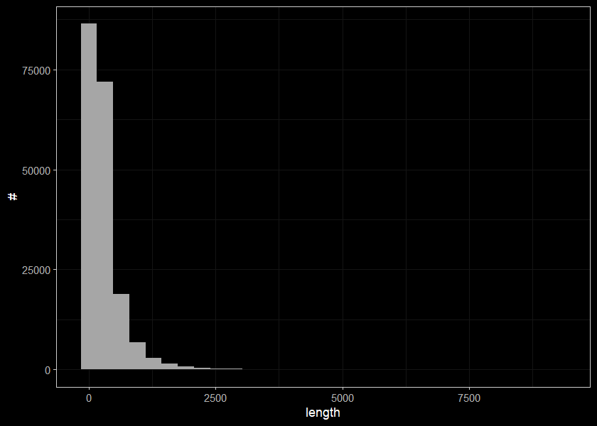

```r
ggplot(select(streams, len), aes(x=len)) +
  geom_histogram(position="identity", size = 0.75)+
  labs(x = "length", y = "#") +
  ggdark::dark_theme_bw(base_size = 11)
```

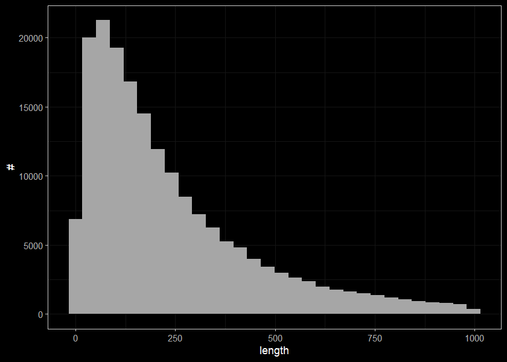

```r
##segments less than 1000m long
ggplot(select(streams, len) %>% filter(len < 1000), aes(x=len)) +
  geom_histogram(position="identity", size = 0.75)+
  labs(x = "length", y = "#") +
  ggdark::dark_theme_bw(base_size = 11)
```

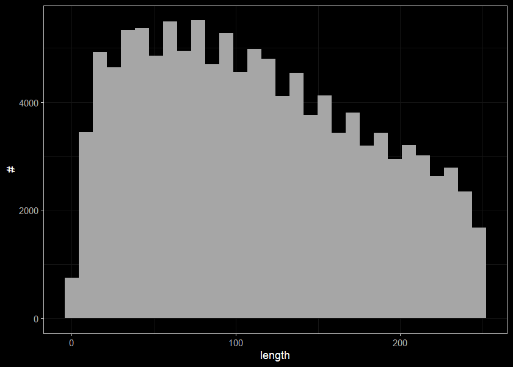

```r
##segments less than 250m long
ggplot(select(streams, len) %>% filter(len < 250), aes(x=len)) +
  geom_histogram(position="identity", size = 0.75)+
  labs(x = "length", y = "#") +
  ggdark::dark_theme_bw(base_size = 11)
```

```r
##how many streams are segments are smaller than 50m
streams %>%
  filter(len > 1000) %>%
  count()
```

```
## # A tibble: 1 x 1
##       n
##   <int>
## 1  8286
```

```r
streams_equal <- streams %>%
  mutate(cut = cut_number(len, n = 5)) %>%
  group_by(cut) %>%
  summarise(n = n())

streams_equal
```

```
## # A tibble: 5 x 2
##   cut                n
##   <fct>          <int>
## 1 [1,70]         38500
## 2 (70,138]       38232
## 3 (138,235]      37768
## 4 (235,427]      38064
## 5 (427,9.25e+03] 38099
```

```r
streams_interval <- streams %>%
  mutate(cut = cut_interval(len, n = 10)) %>%
  group_by(cut) %>%
  summarise(n = n())

streams_interval
```

```
## # A tibble: 10 x 2
##    cut                      n
##    <fct>                <int>
##  1 [1,926]             180821
##  2 (926,1.85e+03]        8096
##  3 (1.85e+03,2.78e+03]   1296
##  4 (2.78e+03,3.7e+03]     294
##  5 (3.7e+03,4.63e+03]      90
##  6 (4.63e+03,5.55e+03]     33
##  7 (5.55e+03,6.48e+03]     21
##  8 (6.48e+03,7.4e+03]       7
##  9 (7.4e+03,8.33e+03]       4
## 10 (8.33e+03,9.25e+03]      1
```

```r
streams_length <- streams %>%
  mutate(cut =
           case_when(
             len < 100 ~ '0_100',
             len >= 100 & len < 500 ~ '0100_500',
             len >= 500 & len < 999 ~ '0500_1000',
             len >=999  ~ '1000+'))

streams_length_sum <- streams_length %>%
  group_by(cut) %>%
  summarise(n = n())

streams_length_sum
```

```
## # A tibble: 4 x 2
##   cut            n
##   <chr>      <int>
## 1 0_100      55821
## 2 0100_500  104540
## 3 0500_1000  21988
## 4 1000+       8314
```

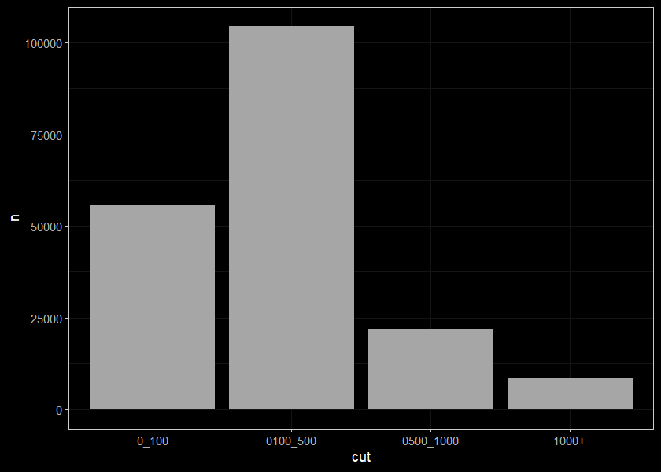

```r
ggplot(data = streams_length_sum, mapping = aes(x=cut, y = n)) +
  geom_bar(stat = "identity") +
  # ylim(1000, 20000)+
  # labs(x='test') +
  ggdark::dark_theme_bw(base_size = 11)
```

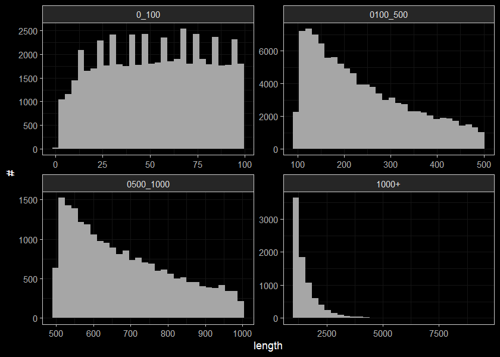

```r
ggplot(streams_length, aes(x=len)) +
  geom_histogram(position="identity", size = 0.75)+
  labs(x = "length", y = "#") +
  facet_wrap(~cut, ncol = 2, scales = "free")+
  ggdark::dark_theme_bw(base_size = 11)
```

# 3 Explore Data Exported from FISS

Purpose of this section is to explore the species density data provided in csv format from the province. We would like to be able to tie density of fish species to habitat characteristics including gradient, channel size, discharge, elevation, forest cover, etc.

Load the data from the dropbox

Make a table that has all the info we want in one place for the summarized fish

```r
d_sum_raw <- left_join(
  d %>% pluck('counts'),
  d %>% pluck('visits'),
  by = 'key'
  ) %>%
  left_join(
    .,
    d %>% pluck('habitat'),
    by = 'key'
  ) %>%
##clean it up and grab a density
  filter(!is.na(fishing_area_length) &
           fishing_area_length > 0 &
           !is.na(fishing_area_width) &
           fishing_area_width > 0 &
           !is.na(utm_easting) &
           !is.na(utm_northing) &
           utm_zone > 0 &
           #For the sake of a first run lets keep only the first passes from sites that have multiple passes
           haul_or_pass == 1 &
           species_code %in% c('RB', 'BT', 'GR', 'CH', 'CO', 'SK', 'WCT', 'ST', 'NFC')) %>%
  mutate(density_100m = number_caught/(fishing_area_length * fishing_area_width) * 100)
```

Lets review how many occurrences are from the same site - not sure it matters though.

```r
d_same_site <- d_sum_raw %>%
  group_by(across(data_set:agncy_id)) %>%
  summarise(n = n()) %>%
  filter(n > 1)
```

Lets have a look at what we have by species.

```r
d_raw_by_sp <- d_sum_raw %>%
  group_by(species_code) %>%
  mutate(area = fishing_area_length * fishing_area_width) %>%
  summarise(n = n(),
            dens_min = min(density_100m, na.rm = T),
            dens_max = max(density_100m, na.rm = T),
            dens_med = median(density_100m, na.rm = T),
            area_min = min(area, na.rm = T),
            area_max = max(area, na.rm = T),
            area_med = median(area, na.rm = T),
            len_min = min(fishing_area_length, na.rm = T),
            len_max = max(fishing_area_length, na.rm = T),
            len_med = median(fishing_area_length, na.rm = T),
            wid_min = min(fishing_area_width, na.rm = T),
            wid_max = max(fishing_area_width, na.rm = T),
            wid_med = median(fishing_area_width, na.rm = T))

d_raw_by_sp
```

```
## # A tibble: 9 x 14
##   species_code     n   dens_min dens_max dens_med area_min  area_max area_med len_min len_max len_med wid_min wid_max wid_med
##   <chr>        <int>      <dbl>    <dbl>    <dbl>    <dbl>     <dbl>    <dbl>   <dbl>   <dbl>   <dbl>   <dbl>   <dbl>   <dbl>
## 1 BT            4398 0.00000500     200     0.571     1    99980001      390      1     9999    100       0.5 10000.      5
## 2 CH            1303 0.000182       848.    2.5       1      549994.     240      1     1600     80       0.7 10000.      3
## 3 CO            3393 0.00855       6292.    6         0.72   549994.     112      1     1950     30       0.3 10000.      3
## 4 GR             770 0.00110        125     0.333    20       91200      600      5     3000    150       0.5   708       4
## 5 NFC          23136 0                0     0         0.1  99998000.     200      0.5  10000.   110       0.1 10000.      1.5
## 6 RB           14500 0            14700     1.33      1    99998000.     250      1    10000.   100       0.1 10000.      4
## 7 SK              80 0.0182         103.    0.558    31        5500      240     16     1600     80       1      20       3
## 8 ST             415 0.0286         382.    7.34     31.3      7500      104.     6     1000     17.5     1.3    61.8     6
## 9 WCT           2240 0              310     1.2       2     7969920.     250      2     3443    100       0.5 10000.      4
```

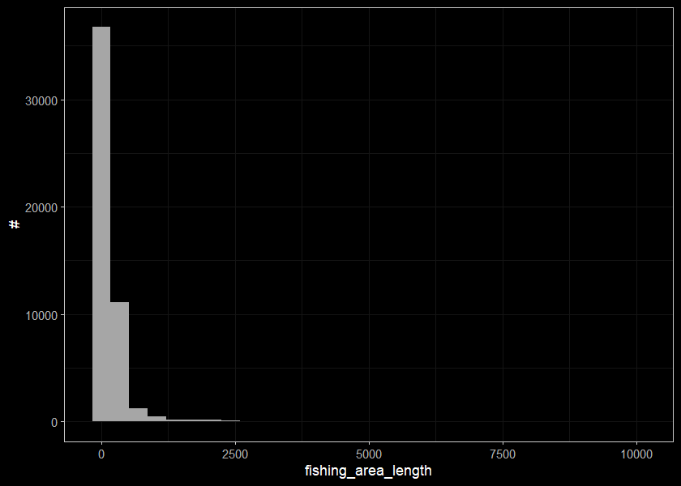

```r
ggplot(select(d_sum_raw, fishing_area_length), aes(x=fishing_area_length)) +
  geom_histogram(position="identity", size = 0.75)+
  labs(x = "fishing_area_length", y = "#") +
  ggdark::dark_theme_bw(base_size = 11)
```

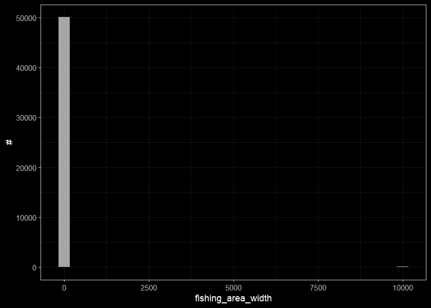

```r
ggplot(select(d_sum_raw, fishing_area_width), aes(x=fishing_area_width)) +
  geom_histogram(position="identity", size = 0.75)+
  labs(x = "fishing_area_width", y = "#") +
  ggdark::dark_theme_bw(base_size = 11)
```

Lets trim out our strange numbers for the site sizes

```r
d_sum <- left_join(
  d %>% pluck('counts'),
  d %>% pluck('visits'),
  by = 'key'
  ) %>%
  left_join(
    .,
    d %>% pluck('habitat'),
    by = 'key'
  ) %>%
##clean it up and grab a density
  filter(!is.na(fishing_area_length) &
           fishing_area_length > 0.9 &
           fishing_area_length < 500.1 &
           !is.na(fishing_area_width) &
           fishing_area_width > 0.5 &
           fishing_area_width < 25.1 &
           !is.na(utm_easting) &
           !is.na(utm_northing) &
           utm_zone > 0 &
           #For the sake of a first run lets keep only the first passes from sites that have multiple passes
           haul_or_pass == 1 &
           species_code %in% c('RB', 'BT', 'GR', 'CH', 'CO', 'SK', 'WCT', 'ST', 'NFC')) %>%
  mutate(density_100m = number_caught/(fishing_area_length * fishing_area_width) * 100)


##have another look at it
d_by_sp <- d_sum %>%
  group_by(species_code) %>%
  mutate(area = fishing_area_length * fishing_area_width) %>%
  summarise(n = n(),
            dens_min = min(density_100m, na.rm = T),
            dens_max = max(density_100m, na.rm = T),
            dens_med = median(density_100m, na.rm = T),
            area_min = min(area, na.rm = T),
            area_max = max(area, na.rm = T),
            area_med = median(area, na.rm = T),
            len_min = min(fishing_area_length, na.rm = T),
            len_max = max(fishing_area_length, na.rm = T),
            len_med = median(fishing_area_length, na.rm = T),
            wid_min = min(fishing_area_width, na.rm = T),
            wid_max = max(fishing_area_width, na.rm = T),
            wid_med = median(fishing_area_width, na.rm = T))

d_by_sp
```

```
## # A tibble: 9 x 14
##   species_code     n dens_min dens_max dens_med area_min area_max area_med len_min len_max len_med wid_min wid_max wid_med
##   <chr>        <int>    <dbl>    <dbl>    <dbl>    <dbl>    <dbl>    <dbl>   <dbl>   <dbl>   <dbl>   <dbl>   <dbl>   <dbl>
## 1 BT            3956  0.01        200     0.667     1       10000     300        1     500   100       0.6    25       4.7
## 2 CH            1282  0.0268      848.    2.60      1        8000     240        1     500    80       0.7    25       3
## 3 CO            3298  0.0291     6292.    6.25      0.72     7500     108.       1     500    30       0.6    25       3
## 4 GR             658  0.00833     125     0.447    20       12000     498.       5     500   150       0.7    25       3.3
## 5 NFC          20100  0             0     0         1       12500     200        1     500   107       0.6    25       1.6
## 6 RB           13299  0         14700     1.58      1       12000     220        1     500   100       0.6    25       3.9
## 7 SK              79  0.0182      103.    0.556    31        5500     240       16     400    80       1      20       3
## 8 ST             397  0.112       382.    8.4      31.3      5000     102        6     410    17.1     1.3    20.4     6
## 9 WCT           2137  0           310     1.26      2        6460     230        2     500   100       0.6    25       4
```

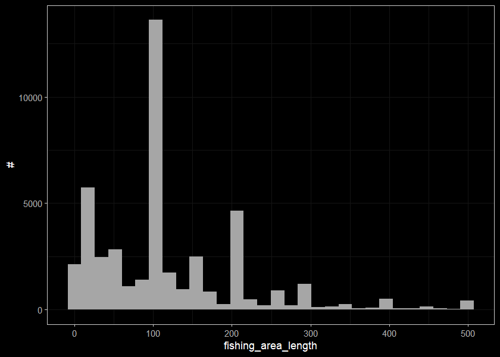

```r
ggplot(select(d_sum, fishing_area_length), aes(x=fishing_area_length)) +
  geom_histogram(position="identity", size = 0.75)+
  labs(x = "fishing_area_length", y = "#") +
  ggdark::dark_theme_bw(base_size = 11)
```

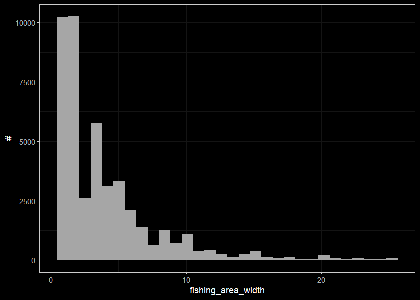

```r
ggplot(select(d_sum, fishing_area_width), aes(x=fishing_area_width)) +
  geom_histogram(position="identity", size = 0.75)+
  labs(x = "fishing_area_width", y = "#") +
  ggdark::dark_theme_bw(base_size = 11)
```

What do the small sites look like? Should we keep them?

```r
length_cut <- 10
width_cut <- 1

sites_small <- d_sum %>%
  filter(fishing_area_length < length_cut |
           fishing_area_width < width_cut) %>%
  mutate(wettedwidth_ave = rowMeans(select(., starts_with("wetted")), na.rm = TRUE)) %>%
  select(fishing_area_length, fishing_area_width, wettedwidth_ave)

sites_small
```

```
## # A tibble: 5,067 x 3
##    fishing_area_length fishing_area_width wettedwidth_ave
##                  <dbl>              <dbl>           <dbl>
##  1                   8                4               NaN
##  2                   8                4               NaN
##  3                   5                2               NaN
##  4                   5                5               NaN
##  5                 100                0.8             NaN
##  6                 200                0.9             NaN
##  7                 200                0.7             NaN
##  8                 200                0.8             NaN
##  9                 200                0.7             NaN
## 10                 200                0.9             NaN
## # ... with 5,057 more rows
```

These are small sites that have associated wetted widths

```r
sites_small %>%
  filter(!is.na(wettedwidth_ave))
```

```
## # A tibble: 2,125 x 3
##    fishing_area_length fishing_area_width wettedwidth_ave
##                  <dbl>              <dbl>           <dbl>
##  1                  80                0.7           0.717
##  2                  67                0.7           0.643
##  3                 100                0.7           0.867
##  4                 100                0.8           0.843
##  5                 100                0.8           0.795
##  6                 100                0.6           0.8
##  7                 100                0.9           0.947
##  8                 200                0.8           0.783
##  9                 100                0.6           0.617
## 10                 100                0.9           0.867
## # ... with 2,115 more rows
```

```r
sites_small_len <- sites_small %>%
  filter(fishing_area_length < length_cut)

sites_small_len
```

```
## # A tibble: 2,266 x 3
##    fishing_area_length fishing_area_width wettedwidth_ave
##                  <dbl>              <dbl>           <dbl>
##  1                   8                  4             NaN
##  2                   8                  4             NaN
##  3                   5                  2             NaN
##  4                   5                  5             NaN
##  5                   1                  1             NaN
##  6                   3                  1             NaN
##  7                   4                  7             NaN
##  8                   7                  3             NaN
##  9                   7                  3             NaN
## 10                   9                  8             NaN
## # ... with 2,256 more rows
```

Distribution of sites with small lengths

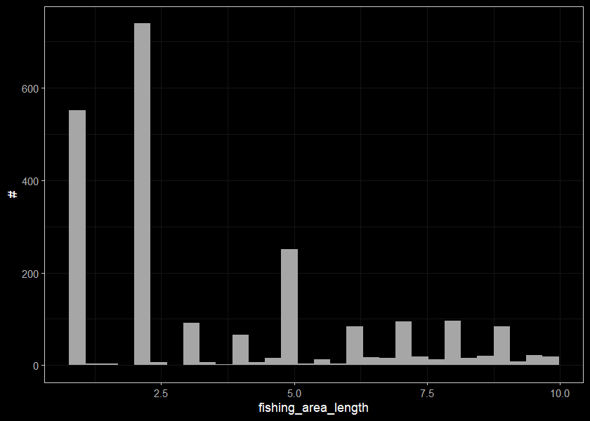

```r
ggplot(select(sites_small_len, fishing_area_length), aes(x=fishing_area_length)) +
  geom_histogram(position="identity", size = 0.75)+
  labs(x = "fishing_area_length", y = "#") +
  ggdark::dark_theme_bw(base_size = 11)
```

Sites with small widths

```r
sites_small_wid <- sites_small %>%
  filter(fishing_area_width < width_cut)

sites_small_wid
```

```
## # A tibble: 2,815 x 3
##    fishing_area_length fishing_area_width wettedwidth_ave
##                  <dbl>              <dbl>           <dbl>
##  1                 100                0.8         NaN
##  2                 200                0.9         NaN
##  3                 200                0.7         NaN
##  4                 200                0.8         NaN
##  5                 200                0.7         NaN
##  6                 200                0.9         NaN
##  7                 200                0.8         NaN
##  8                 250                0.6         NaN
##  9                  80                0.7           0.717
## 10                  67                0.7           0.643
## # ... with 2,805 more rows
```

Distribution of sites with small widths. Are these sites where it was a presence/absence test so maybe not suitable for density modelling? Don’t know…

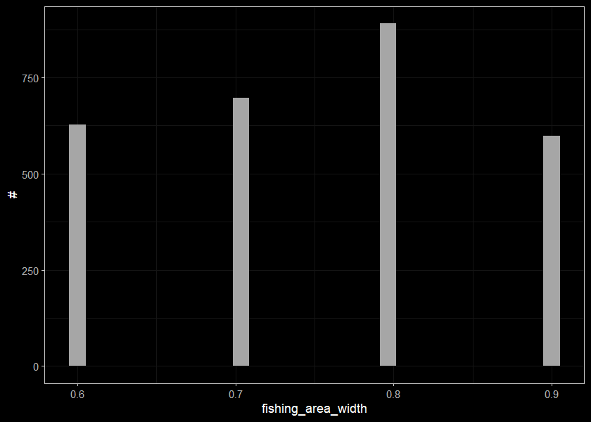

```r
ggplot(select(sites_small_wid, fishing_area_width), aes(x=fishing_area_width)) +
  geom_histogram(position="identity", size = 0.75)+
  labs(x = "fishing_area_width", y = "#") +
  ggdark::dark_theme_bw(base_size = 11)
```

# 4 Make FISS data spatial

We need in spatial format to tie to the FWA so lets put everything in albers and add the X and Y to the dataframe

```r
d_sum_albers <- d_sum %>%
  dplyr::group_split(utm_zone) %>%
  map(utm_to_coord) %>%
  bind_rows()
```

Burn to a csv so that Simon can access and join to habitat characteristics

```r
d_sum_albers %>% readr::write_csv(file = paste0(getwd(), '/data/fiss_density.csv'))
```

Next steps?:

- While Joe and Nadine tweak the channel-width-21 analysis and have a look at what data from here they think we should keep or throw away…
- Simon maybe burns dataframe into postgres that represents the X and Y locations of these sites and ties the locations of the sites to stream segments then pulls out everything he can about the watershed upstream (ex. elevation, watershed size, channel width, discharge, BEC zone, precip, etc ). Future considerations include perhaps forest cover, geology, channel confinement, [Variable Infiltration Capacity (VIC-GL) model stuff](https://www.pacificclimate.org/data/gridded-hydrologic-model-output))
- We should QA how well the sites tie to streams and find a way to filter out (or correct) bad matches if possible.
- Feed results back to Joe and Nadine to see what we can gleen from the data.